# Univariate Poisson Model

Petr Keil

June 2021

This brief lesson introduces the concept of **discrete distribution** (**probability mass function**) on the example of Poisson distribution. We will also do more likelihood stuff.

Optional functions for interactive plotting for those with R-studio:

```r
library(manipulate)

source("https://raw.githubusercontent.com/petrkeil/ML_and_Bayes_2017_iDiv/master/Univariate%20Poisson%20Model/plotting_poisson.r")
```

# 1 Poisson distribution

Poisson distribution is a simple model for discrete and **positive count data**.

$$p\left( x \right) = \frac{{e^{ - \lambda } \lambda ^x }}{{x!}}$$

Where $\lambda$ is the only parameter, which is also the mean of the distribution.

# 2 Simulating poisson data

Let’s explore the Poisson model a bit and simulate some data using `rpois()`:

```r
rpois(n=100, lambda=1)
```

```
##   [1] 1 0 3 2 0 1 0 1 0 1 0 1 0 1 2 0 0 2 0 0 1 1 0 2 2 5 0 0 0 0 0 2 0 0 0 0 0
##  [38] 0 1 4 1 2 1 0 2 1 0 3 0 2 0 1 0 3 2 1 0 1 2 0 0 1 1 1 1 0 0 2 1 1 0 2 1 0
##  [75] 2 4 0 0 1 2 1 1 1 0 1 3 1 1 2 0 2 1 0 0 1 0 3 1 0 1
```

Now try different values of $\lambda$.

We can plot the “empirical frequency histogram” for simulated data with 3 different values of parameter $\lambda$:

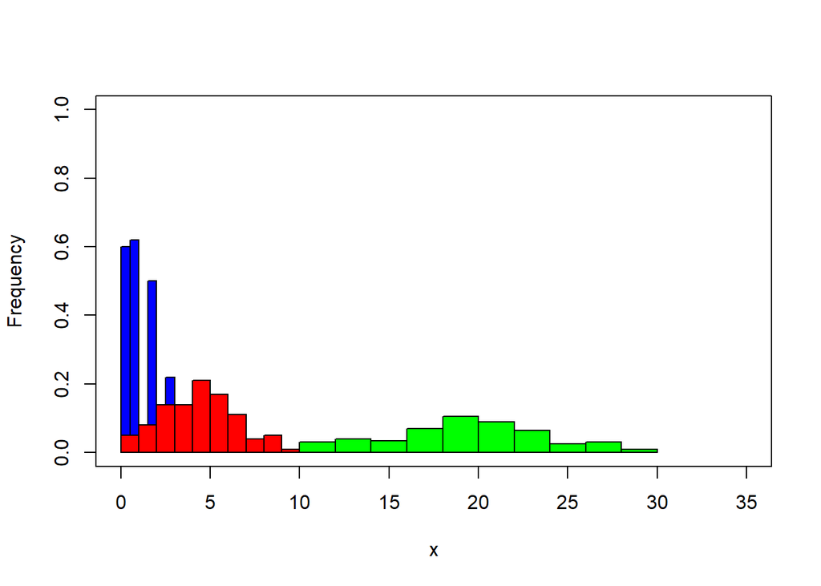

```r
  plot(c(0,35), c(0,1), type="n",
       xlab="x", ylab="Frequency")

  hist(rpois(n=100, lambda=1), add=T, freq=FALSE, col="blue")
  hist(rpois(n=100, lambda=5), add=T, freq=FALSE, col="red")
  hist(rpois(n=100, lambda=20), add=T, freq=FALSE, col="green")
```

Let’s plot the respective **probability mass functions**:

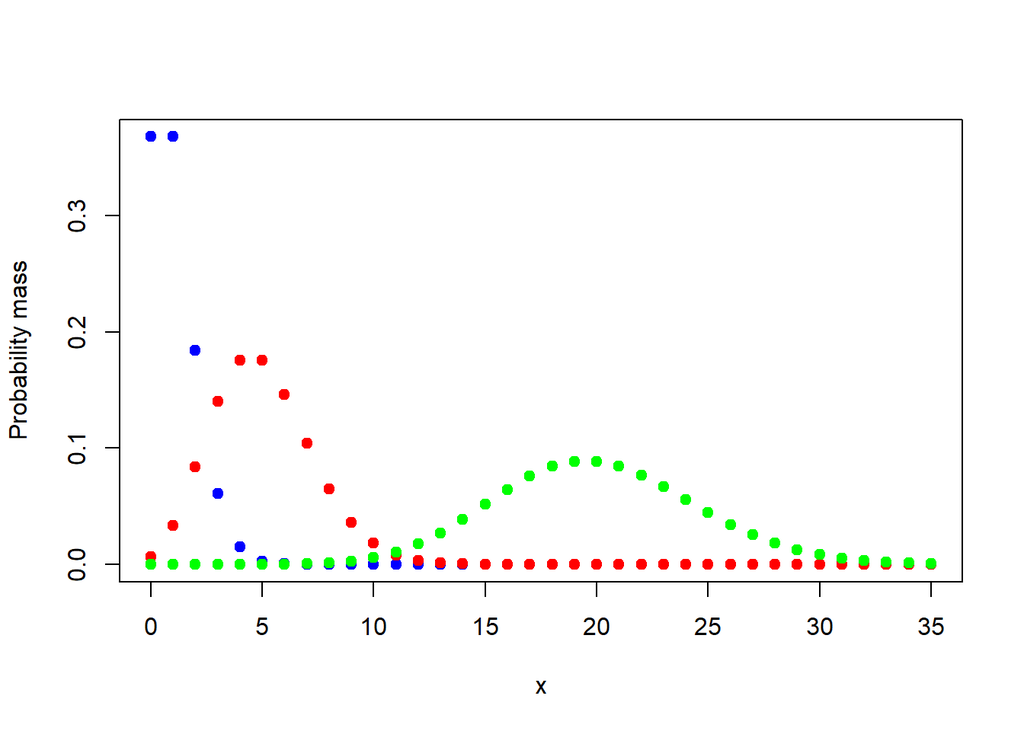

```r
  plot(0:35, dpois(0:35, lambda=1),
       col="blue", pch=19,
       ylab="Probability mass",
       xlab="x")
  points(0:35, dpois(0:35, lambda=5), col="red", pch=19)
  points(0:35, dpois(0:35, lambda=20), col="green", pch=19)
```

Interactive version

```r
manipulate(move.poisson(lambda),
           lambda=slider(1,100, step=0.01))
```

# 3 Poisson likelihood

I will generate the artificial data again:

```r
x <- rpois(n=100, lambda=8)
x
```

```
##   [1]  7 11  6  6  9  5  8 10 10  5  8  5 12 11  9 12  6 10  6  7 14  5  8  7  6
##  [26]  8  2  8 12  7  5 12  6 10  8  7  7  5  6  9  9  9 13  6 12 10 10  6 12 11
##  [51]  8 10  7  2  7  6  7 12 17  7  8  6  7 14  6  5  5  6  8  5 15  9  5 10  6
##  [76] 11  5  6  6 10  9  4  5  5  6  9  6 13 10 13  4 13  7  7 13  3  8 11  8  6
```

Poisson distribution is didactically convenient as it only has the one parameter $\lambda$. We can write the *negative log-likelihood* function for a given dataset $x$:

```r
  negLL.function <- function(x, lambda)
  {
    LL <- dpois(x, lambda, log=TRUE) # the log likelihood
    negLL <- -sum(LL)
    return(negLL)
  }
```

We can try different values of $\lambda$:

```r
  negLL.function(x, lambda=10)
```

```
## [1] 266.8921
```

```r
  lambdas <- seq(0, 30, by=0.1)
  negLL.vector <- numeric(0) # empty numeric vector

  for(i in 1:length(lambdas))
  {
    negLL.vector[i] <- negLL.function(x, lambdas[i])
  }
```

Let’s check what we have:

```r
  negLL.vector
```

```
##   [1]       Inf 3002.4748 2451.7187 2133.6974 1910.9627 1740.4395 1602.9414
##   [8] 1488.2335 1390.2066 1304.9201 1229.6834 1162.5775 1102.1853 1047.4308
##  [15]  997.4774  951.6622  909.4505  870.4052  834.1640  800.4237  768.9274
##  [22]  739.4561  711.8214  685.8600  661.4292  638.4042  616.6747  596.1428
##  [29]  576.7213  558.3325  540.9061  524.3791  508.6944  493.8002  479.6491
##  [36]  466.1982  453.4080  441.2422  429.6676  418.6534  408.1713  398.1950
##  [43]  388.7001  379.6639  371.0654  362.8848  355.1039  347.7054  340.6732
##  [50]  333.9922  327.6482  321.6279  315.9186  310.5086  305.3867  300.5422
##  [57]  295.9653  291.6463  287.5764  283.7470  280.1500  276.7778  273.6231
##  [64]  270.6788  267.9384  265.3955  263.0441  260.8785  258.8931  257.0826
##  [71]  255.4421  253.9668  252.6519  251.4931  250.4861  249.6269  248.9115
##  [78]  248.3362  247.8973  247.5915  247.4152  247.3654  247.4389  247.6327
##  [85]  247.9440  248.3699  248.9078  249.5551  250.3093  251.1680  252.1288
##  [92]  253.1894  254.3478  255.6018  256.9493  258.3884  259.9171  261.5336
##  [99]  263.2361  265.0228  266.8921  268.8423  270.8718  272.9790  275.1626
```

[output cut: 28 more lines]

Our **maximum likelihood exstimate (MLE) of $\lambda$** is:

```r
MLE <- lambdas[which.min(negLL.vector)]
MLE
```

```
## [1] 8.1
```

And this is the plot of the negative log-likelihood function, together with the MLE (vertical line):

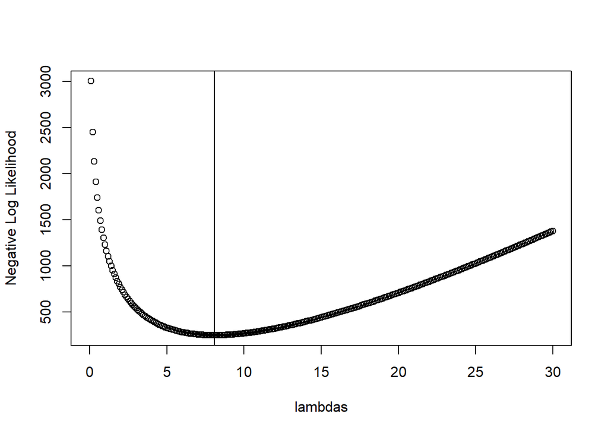

```r
plot(lambdas, negLL.vector, ylab="Negative Log Likelihood")
abline(v=MLE)
```

Interactive visualization:

```r
manipulate(plot.poisson.ll(x, lambda),
           lambda = slider(1, 20, step = 0.01))
```

# 4 Link between log likelihood and deviance

Lunn et al. (2013, p. 138) define **deviance** as:

$$D = -2 \log p(y|\theta)$$
which is two times the negative likelihood!

# 5 Link between log likelihood and AIC

Simply:

$$AIC = D + 2k$$

where $k$ is number of parameters. So for our best estimate ($\lambda = 8$), AIC will be:

```r
  AIC = 2*negLL.function(x, lambda=MLE) + 2*1
  AIC
```

```
## [1] 496.7308
```

We can compare this with the output of `glm` function:

```r
 glm(x~1, family="poisson")
```

```
##
## Call:  glm(formula = x ~ 1, family = "poisson")
##
## Coefficients:
## (Intercept)
##       2.091
##
## Degrees of Freedom: 99 Total (i.e. Null);  99 Residual
## Null Deviance:       106.5
## Residual Deviance: 106.5     AIC: 496.7
```

Note, the deviance here is different from our definition, since GLM seems to report **saturated** version of deviance (Lunn et al. 2013, p. 144)